# Pf6 analysis

Aris Paschalidis

2022-01-27

In this analysis file, we examine the result of running our novel algorithms on the Pf6 dataset. Additionally, we compare the results of our algorithm with the current state of the art model for predicting COI – THE REAL McCOIL.

We first load in our data.

```r
# Path to data
path <- "~/Desktop/Malaria/COI data/"

# Read in the real data and the REAL McCOIL COI predictions
rmcl_wsafs <- readRDS(paste0(path, "RMCL_wsafs_unique.rds"))
rmcl_coi_out <- readRDS(paste0(path, "RMCL_coi_out.rds")) %>%
  tibble::as_tibble() %>%
  dplyr::mutate(dplyr::across(c(file, name), as.character)) %>%
  dplyr::rename(rmcl = COI) %>%
  dplyr::rename(rmcl_025 = COI_025) %>%
  dplyr::rename(rmcl_975 = COI_975)
```

```r
complete_predictions <- readRDS(here::here(
  "data-outputs",
  "freq_variation.rds"
))
```

## Evaluate predictions

We first reshape our data so that we have a single column with our COI estimates. This involves creating two new additional column to represent the coi_method and optimization method we used to compute the COI.

```r
pivot_data <- complete_predictions %>%
  tidyr::pivot_longer(
    cols = dplyr::starts_with(c("dis", "cont")),
    names_to = c(".value", "coi_method"),
    names_pattern = "(.*)_(.*)_.*"
  ) %>%
  tidyr::pivot_longer(
    cols = dplyr::any_of(c("dis", "cont")),
    names_to = "optimization",
    values_to = "COI",
    values_drop_na = TRUE
  ) %>%
  dplyr::relocate(
    dplyr::any_of(c("coi_method", "optimization", "COI")),
    .after = name
  ) %>%
  dplyr::filter(rmcl_med != 25 & !is.na(rmcl_med))
```

We can next plot all our estimates and further include the deviation from the median THE REAL McCOIL estimation.

```r
var_data <- dplyr::filter(pivot_data, coi_method == "var")

var_panel <- ggplot(
  data = var_data,
  mapping = aes(y = COI, x = rmcl_med, color = optimization)
) +
  scale_size_area() +
  geom_abline(color = "gray", size = 0.5) +
  geom_count(
    data = dplyr::filter(var_data, optimization != "dis"),
    alpha = 0.8,
    position = position_jitter(width = 0.1)
  ) +
  geom_count(
    data = dplyr::filter(var_data, optimization == "dis"),
    alpha = 0.8
  ) +
  theme_coiaf() +
  labs(
    title = "Variant Method",
    y = "coiaf Prediction",
    color = "Optimization Method"
  ) +
  scale_color_manual(
    labels = c("Continuous", "Discrete"),
    values = c("#00239CFF", "#E10600FF")
  ) +
  guides(size = "none") +
  scale_x_continuous("THE REAL McCOIL Prediction", breaks = seq(0, 10))
```

```r
freq_data <- dplyr::filter(pivot_data, coi_method != "var")

freq_panel <- ggplot(
  data = freq_data,
  mapping = aes(y = COI, x = rmcl_med, color = optimization)
) +
  scale_size_area() +
  geom_abline(color = "gray", size = 0.5) +
  geom_count(
    data = dplyr::filter(freq_data, optimization != "dis"),
    alpha = 0.8,
    position = position_jitter(width = 0.1)
  ) +
  geom_count(
    data = dplyr::filter(freq_data, optimization == "dis"),
    alpha = 0.8
  ) +
  theme_coiaf() +
  labs(
    title = "Frequency Method",
    y = "coiaf Prediction",
    color = "Optimization Method"
  ) +
  scale_color_manual(
    labels = c("Continuous", "Discrete"),
    values = c("#00239CFF", "#E10600FF")
  ) +
  guides(size = "none") +
  scale_x_continuous("THE REAL McCOIL Prediction", breaks = seq(0, 10))
```

```r
diff_panel <- ggplot(pivot_data, aes(x = COI - rmcl_med, fill = coi_method)) +
  geom_density(alpha = 0.6) +
  labs(x = "COI - Median RMCL", y = "Density", fill = "COI Method") +
  scale_fill_manual(
    labels = c("Variant", "Frequency"),
    values = c("#4B878BFF", "#D01C1FFF")
  ) +
  theme_coiaf() +
  theme(legend.position = "right")
```

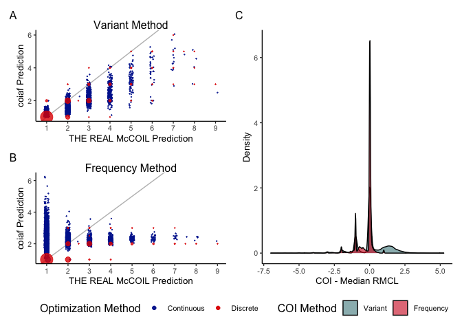

```r
# Use patchwork to combine plots
patchwork <- (var_panel / freq_panel) | diff_panel
patchwork +
  plot_annotation(tag_levels = "A") +
  plot_layout(guides = "collect") &
  theme(legend.position = "bottom")
```

```r
wide_data <- pivot_data %>%
  tidyr::pivot_wider(
    names_from = c(coi_method, optimization),
    names_prefix = "coiaf_",
    values_from = COI
  )

corrr <- wide_data %>%
  dplyr::select(dplyr::starts_with("coiaf"), rmcl_med) %>%
  corrr::correlate()
```

```
#>
#> Correlation method: 'pearson'
#> Missing treated using: 'pairwise.complete.obs'
```

```r
corrr::focus(corrr, rmcl_med)
```

```
#> # A tibble: 4 × 2
#>   term            rmcl_med
#>   <chr>              <dbl>
#> 1 coiaf_var_dis     0.877
#> 2 coiaf_var_cont    0.913
#> 3 coiaf_freq_dis    0.775
#> 4 coiaf_freq_cont   0.0230
```

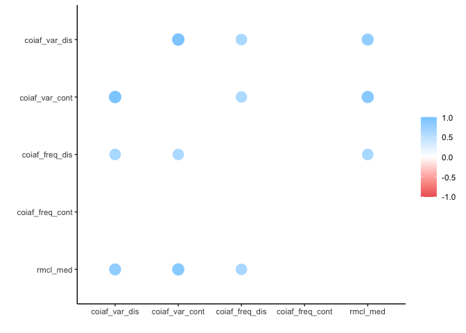

```r
corrr::rplot(corrr)
```

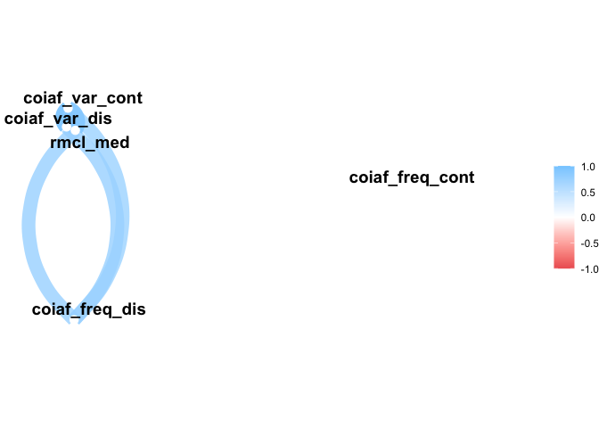

```r
corrr::network_plot(corrr)
```

```r
lm(rmcl_med ~ coiaf_var_dis, data = wide_data) %>% broom::glance()
```

```
#> # A tibble: 1 × 12
#>   r.squared adj.r.squared sigma statistic p.value    df logLik   AIC   BIC
#>       <dbl>         <dbl> <dbl>     <dbl>   <dbl> <dbl>  <dbl> <dbl> <dbl>
#> 1     0.769         0.769 0.503    17153.       0     1 -3771. 7548. 7567.
#> # … with 3 more variables: deviance <dbl>, df.residual <int>, nobs <int>
```

```r
lm(rmcl_med ~ coiaf_var_cont, data = wide_data) %>% broom::glance()
```

```
#> # A tibble: 1 × 12
#>   r.squared adj.r.squared sigma statistic p.value    df logLik   AIC   BIC
#>       <dbl>         <dbl> <dbl>     <dbl>   <dbl> <dbl>  <dbl> <dbl> <dbl>
#> 1     0.833         0.833 0.428    25749.       0     1 -2931. 5868. 5888.
#> # … with 3 more variables: deviance <dbl>, df.residual <int>, nobs <int>
```

```r
lm(rmcl_med ~ coiaf_freq_dis, data = wide_data) %>% broom::glance()
```

```
#> # A tibble: 1 × 12
#>   r.squared adj.r.squared sigma statistic p.value    df logLik    AIC    BIC
#>       <dbl>         <dbl> <dbl>     <dbl>   <dbl> <dbl>  <dbl>  <dbl>  <dbl>
#> 1     0.600         0.600 0.662     7737.       0     1 -5183. 10373. 10392.
#> # … with 3 more variables: deviance <dbl>, df.residual <int>, nobs <int>
```

```r
lm(rmcl_med ~ coiaf_freq_cont, data = wide_data) %>% broom::glance()
```

```
#> # A tibble: 1 × 12
#>   r.squared adj.r.squared sigma statistic p.value    df logLik    AIC    BIC
#>       <dbl>         <dbl> <dbl>     <dbl>   <dbl> <dbl>  <dbl>  <dbl>  <dbl>
#> 1  0.000527      0.000333  1.05      2.72  0.0994     1 -7545. 15095. 15115.
#> # … with 3 more variables: deviance <dbl>, df.residual <int>, nobs <int>
```

### COI by region

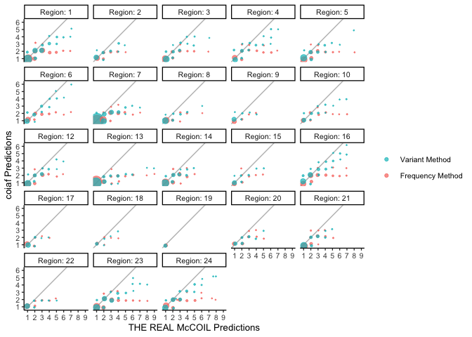

```r
# Only discrete
ggplot(
  data = dplyr::filter(pivot_data, optimization == "dis"),
  mapping = aes(y = COI, x = rmcl_med, color = coi_method)
) +
  scale_size_area() +
  geom_abline(color = "gray", size = 0.5) +
  geom_count(alpha = 0.7, position = position_jitter(width = 0.1)) +
  facet_wrap(.~ Region, labeller = label_both) +
  scale_x_continuous("THE REAL McCOIL Predictions", breaks = seq(1, 10)) +
  scale_y_continuous("coiaf Predictions", breaks = seq(1, 10)) +
  scale_color_discrete(
    name = NULL,
    breaks = c("var", "freq"),
    labels = c("Variant Method", "Frequency Method")
  ) +
  theme_coiaf() +
  guides(size = "none")
```

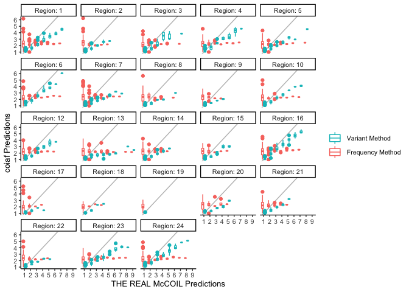

```r
# Only continuous
ggplot(
  data = dplyr::filter(pivot_data, optimization == "cont"),
  mapping = aes(y = COI, x = cut_width(rmcl_med, 1), color = coi_method)
) +
  geom_abline(color = "gray", size = 0.5) +
  geom_boxplot() +
  facet_wrap(.~ Region, labeller = label_both) +
  scale_x_discrete("THE REAL McCOIL Predictions", labels = seq(1, 10)) +
  scale_y_continuous("coiaf Predictions", breaks = seq(1, 10)) +
  scale_color_discrete(
    name = NULL,
    breaks = c("var", "freq"),
    labels = c("Variant Method", "Frequency Method")
  ) +
  theme_coiaf() +
  guides(size = "none")
```

## World maps

We need to access the Pf6 metadata in order to create a world map as the metadata contains information about the latitude and longitude of each sample.

```r
meta <- readRDS(here::here("metadata", "pf6_meta.rds"))

patient_lat_long <- dplyr::left_join(
  complete_predictions, meta,
  by = c("name" = "Sample")
)
```

```r
patient_lat_long %>%
  dplyr::count(Continent, Subregion) %>%
  dplyr::mutate(proportion = n / sum(n) * 100) %>%
  dplyr::arrange(Continent, Subregion)
```

```
#> # A tibble: 7 × 4
#>   Continent Subregion              n proportion
#>   <chr>     <chr>              <int>      <dbl>
#> 1 Africa    Eastern Africa       739      12.3
#> 2 Africa    Middle Africa        579       9.65
#> 3 Africa    Western Africa      1996      33.3
#> 4 Americas  South America         68       1.13
#> 5 Asia      South-Eastern Asia  2421      40.3
#> 6 Asia      Southern Asia         77       1.28
#> 7 Oceania   Melanesia            121       2.02
```

We can then generate several world maps with our data!

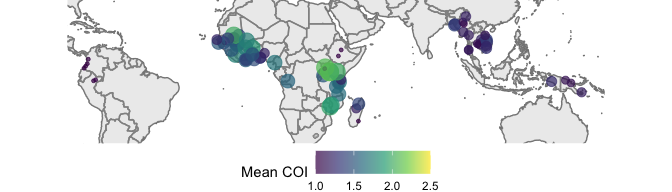

```r
# Get average of data
map_average <- patient_lat_long %>%
  dplyr::group_by(Region, Lat, Long) %>%
  dplyr::summarise(
    coi_mean = mean(dis_var_med),
    coi_med = median(dis_freq_med),
    prev = median(as.numeric(prev_2_10)),
    rmcl_med = median(rmcl_med),
    .groups = "drop"
  ) %>%
  dplyr::rename(lat = Lat) %>%
  dplyr::rename(long = Long)

# Plot the mean COI
mean_world <- world_map(
  map_average,
  coi_mean,
  label = "Mean COI",
  alpha = 0.7,
  breaks = c(1.0, 1.5, 2.0, 2.5)
)
mean_world
```

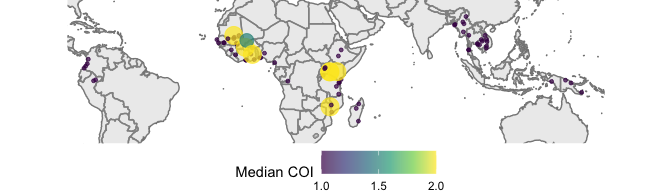

```r
# Plot the median COI
med_world <- world_map(
  map_average,
  coi_med,
  label = "Median COI",
  alpha = 0.7,
  breaks = c(1.0, 1.5, 2.0)
)
med_world
```

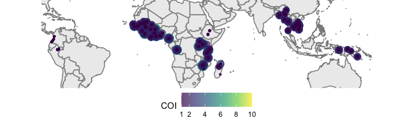

```r
# Get data that has a COI of less than 10. This is done for now as we suspect
# there are some samples that are wrong! Regions that predict 25!
# The two patients are: "PN0075-C" and "PT0069-C"
# We also set up data to be descending so that smaller COIs stay on top.
all_world_map <- patient_lat_long %>%
  dplyr::arrange(desc(dis_var_med)) %>%
  dplyr::rename(lat = Lat) %>%
  dplyr::rename(long = Long)

# Plot all patient COIs (theme is added so that there is less whitespace)
all_world <- world_map(
  all_world_map,
  dis_var_med,
  "COI",
  alpha = 0.7,
  breaks = c(1, 2, 4, 6, 8, 10)
)
all_world
```

```r
# Mean, median COI per continent
patient_lat_long %>%
  dplyr::group_by(Continent) %>%
  dplyr::summarise(
    mean = mean(dis_var_med, na.rm = TRUE),
    median = median(dis_var_med, na.rm = TRUE),
    .groups = "drop"
  )
```

```
#> # A tibble: 4 × 3
#>   Continent  mean median
#>   <chr>     <dbl>  <dbl>
#> 1 Africa     1.64      1
#> 2 Americas   1         1
#> 3 Asia       1.18      1
#> 4 Oceania    1.12      1
```

```r
# KW across 24 regions
kruskal.test(dis_var_med ~ Continent, data = patient_lat_long)
```

```
#>
#>  Kruskal-Wallis rank sum test
#>
#> data:  dis_var_med by Continent
#> Kruskal-Wallis chi-squared = 612.59, df = 3, p-value < 2.2e-16
```

```r
# KW across subregions of continents
kruskal.test(dis_var_med ~ Subregion, data = patient_lat_long)
```

```
#>
#>  Kruskal-Wallis rank sum test
#>
#> data:  dis_var_med by Subregion
#> Kruskal-Wallis chi-squared = 622.43, df = 6, p-value < 2.2e-16
```

```r
# Post hoc Nemenyi test
pvalue_continent <- PMCMRplus::kwAllPairsNemenyiTest(
  dis_var_med ~ as.factor(Continent),
  data = patient_lat_long
)$p.value
purrr::map_df(tibble::as_tibble(pvalue_continent), ~ round(.x, digits = 5)) %>%
  tibble::add_column(Continent = rownames(pvalue_continent), .before = 1)
```

```
#> # A tibble: 3 × 4
#>   Continent  Africa Americas   Asia
#>   <chr>       <dbl>    <dbl>  <dbl>
#> 1 Americas  0.00003   NA     NA
#> 2 Asia      0          0.404 NA
#> 3 Oceania   0          0.810  0.718
```

```r
patient_lat_long %>%
  dplyr::group_by(Continent, Subregion) %>%
  dplyr::summarise(
    mean = mean(dis_var_med, na.rm = TRUE),
    median = median(dis_var_med, na.rm = TRUE),
    .groups = "drop"
  )
```

```
#> # A tibble: 7 × 4
#>   Continent Subregion           mean median
#>   <chr>     <chr>              <dbl>  <dbl>
#> 1 Africa    Eastern Africa      1.66      1
#> 2 Africa    Middle Africa       1.63      1
#> 3 Africa    Western Africa      1.64      1
#> 4 Americas  South America       1         1
#> 5 Asia      South-Eastern Asia  1.17      1
#> 6 Asia      Southern Asia       1.36      1
#> 7 Oceania   Melanesia           1.12      1
```

```r
pvalue_subregion <- PMCMRplus::kwAllPairsNemenyiTest(
  dis_var_med ~ as.factor(Subregion),
  data = patient_lat_long
)$p.value
purrr::map_df(tibble::as_tibble(pvalue_subregion), ~ round(.x, digits = 5)) %>%
  tibble::add_column(Subregion = rownames(pvalue_subregion), .before = 1)
```

```
#> # A tibble: 6 × 7
#>   Subregion          `Eastern Africa` Melanesia `Middle Africa` `South America`
#>   <chr>                         <dbl>     <dbl>           <dbl>           <dbl>
#> 1 Melanesia                    0         NA            NA              NA
#> 2 Middle Africa                0.996      0            NA              NA
#> 3 South America                0.0002     0.974         0.00009        NA
#> 4 South-Eastern Asia           0          0.963         0               0.741
#> 5 Southern Asia                0.428      0.136         0.274           0.114
#> 6 Western Africa               1          0             0.991           0.00015
#> # … with 2 more variables: South-Eastern Asia <dbl>, Southern Asia <dbl>
```

## Prevalence & FwS

We can also look at the relationship between our COI estimations and the prevalence of mutations as well as the FwS metric.

```r
prev_fws <- patient_lat_long %>%
  dplyr::filter(rmcl_med != 25 & !is.na(rmcl_med)) %>%
  tidyr::pivot_longer(dplyr::any_of(c("dis_var_med", "rmcl_med")),
    names_to = "Method",
    values_to = "COI",
    values_drop_na = TRUE
  ) %>%
  dplyr::select(name, Region:Long, prev_2_10:COI) %>%
  dplyr::mutate(
    prev = as.numeric(prev_2_10),
    Method = dplyr::recode(
      Method,
      dis_var_med = "Discrete Variant Method",
      rmcl_med = "THE REAL McCOIL"
    ),
    .keep = "unused"
  )
```

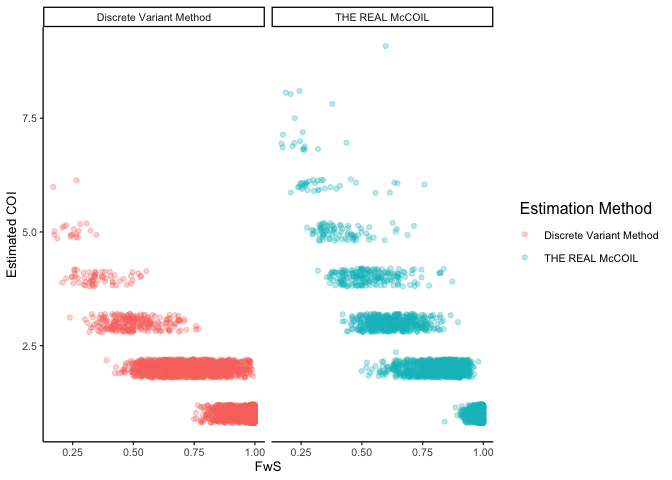

```r
# FwS
ggplot(data = prev_fws, aes(x = Fws, y = COI, color = Method)) +
  geom_point(alpha = 0.3, position = position_jitter(height = 0.2)) +
  labs(x = "FwS", y = "Estimated COI") +
  facet_grid(~Method) +
  scale_color_discrete(
    name = "Estimation Method",
    labels = c("Discrete Variant Method", "THE REAL McCOIL")
  ) +
  theme_coiaf()
```

```r
# Correlation
coiaf_fws <- dplyr::filter(prev_fws, Method == "Discrete Variant Method")
cor.test(coiaf_fws$Fws, coiaf_fws$COI)
```

```
#>
#>  Pearson's product-moment correlation
#>
#> data:  coiaf_fws$Fws and coiaf_fws$COI
#> t = -149.34, df = 5149, p-value < 2.2e-16
#> alternative hypothesis: true correlation is not equal to 0
#> 95 percent confidence interval:
#>  -0.9063533 -0.8961026
#> sample estimates:
#>        cor
#> -0.9013541
```

```r
rmcl_fws <- dplyr::filter(prev_fws, Method == "THE REAL McCOIL")
cor.test(rmcl_fws$Fws, rmcl_fws$COI)
```

```
#>
#>  Pearson's product-moment correlation
#>
#> data:  rmcl_fws$Fws and rmcl_fws$COI
#> t = -188, df = 5184, p-value < 2.2e-16
#> alternative hypothesis: true correlation is not equal to 0
#> 95 percent confidence interval:
#>  -0.9372501 -0.9302825
#> sample estimates:
#>        cor
#> -0.9338549
```

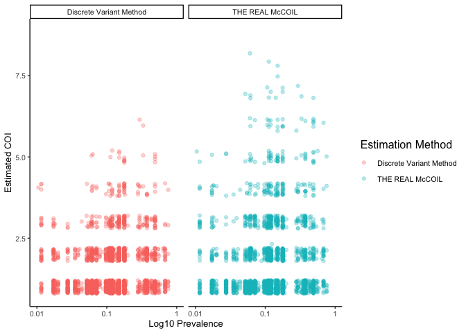

```r
# Prevalence
ggplot(data = prev_fws, aes(x = prev, y = COI, color = Method)) +
  geom_point(alpha = 0.3, position = position_jitter(height = 0.2)) +
  scale_x_log10(
    breaks = c(0.01, 0.1, 1),
    labels = c(0.01, 0.1, 1),
    limits = c(0.01, 1)
  ) +
  facet_grid(~Method) +
  labs(x = "Log10 Prevalence", y = "Estimated COI") +
  scale_color_discrete(
    name = "Estimation Method",
    labels = c("Discrete Variant Method", "THE REAL McCOIL")
  ) +
  theme_coiaf()
```

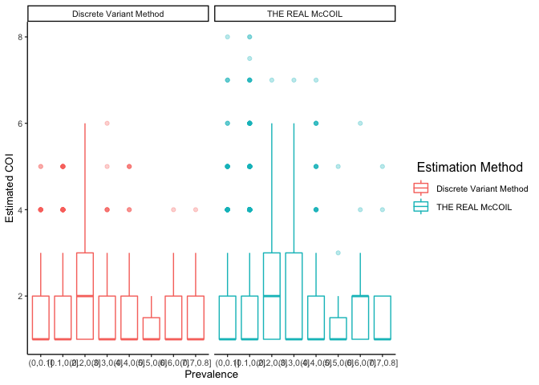

```r
ggplot(
  data = tidyr::drop_na(prev_fws),
  aes(
    x = cut(prev, seq(0, 1, 0.1), right = TRUE),
    y = COI, color = Method
  )
) +
  geom_boxplot(alpha = 0.3) +
  facet_grid(~Method) +
  labs(x = "Prevalence", y = "Estimated COI") +
  scale_color_discrete(
    name = "Estimation Method",
    labels = c("Discrete Variant Method", "THE REAL McCOIL")
  ) +
  theme_coiaf()
```

```r
filter_data <- patient_lat_long %>%
  dplyr::select(!dplyr::starts_with("rmcl")) %>%
  tidyr::pivot_longer(
    cols = dplyr::starts_with(c("dis_", "cont_")),
    names_to = c(".value", "coi_method"),
    names_pattern = "(.*)_(.*)_.*"
  ) %>%
  tidyr::pivot_longer(
    cols = dplyr::any_of(c("dis", "cont")),
    names_to = "optimization",
    values_to = "COI",
    values_drop_na = TRUE
  ) %>%
  dplyr::relocate(
    dplyr::any_of(c("coi_method", "optimization", "COI")),
    .after = name
  ) %>%
  dplyr::filter(coi_method == "var" & optimization == "dis")

continents <- filter_data %>%
  dplyr::group_by(Region) %>%
  dplyr::mutate(med_prev = median(prev_2_10, na.rm = TRUE)) %>%
  dplyr::filter(med_prev != 0) %>%
  dplyr::arrange(prev_2_10) %>%
  dplyr::ungroup() %>%
  dplyr::mutate(Region = forcats::as_factor(Region))

sorted_prev <- continents %>%
  dplyr::select(Region, med_prev) %>%
  dplyr::distinct() %>%
  dplyr::pull(med_prev) %>%
  sort()

ridges <- ggplot(
  data = continents,
  aes(y = forcats::fct_reorder(Region, med_prev), x = COI, fill = Subregion)
) +
  ggridges::geom_density_ridges() +
  ggridges::theme_ridges() +
  theme_coiaf() +
  scale_fill_viridis_d() +
  annotate(
    "text",
    x = 6.25,
    y = 1:17 + 0.3,
    label = round(sorted_prev, 2),
    size = 2.5
  ) +
  labs(x = "COI", y = "Region")
```

Combining our world map plots and our prevalence plot, we can generate an informative picture of COI in the world.

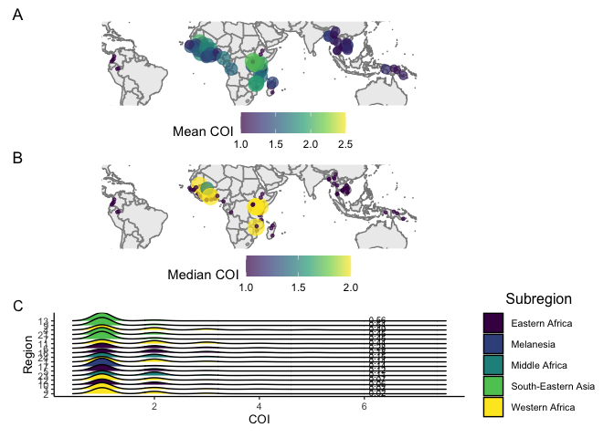

```r
mean_world / med_world / ridges +
  plot_annotation(tag_levels = "A") +
  plot_layout(widths = c(2, 2, 1))
```